# TwoWay_anova

Heloiza de Oliveira

## ANOVA de dois fatores em experimentos fatoriais

### Delineamento inteiramente ao acaso

##### Problema 1

O rendimento de um processo químico está sendo estudado. As duas variáveis mais importantes são consideradas a pressão (psig) e a temperatura (°C). Três níveis de cada fator são selecionados, e um experimento fatorial com duas repetições é realizado. Os dados de rendimento são os seguintes:

```r
rm(list = ls())

quimico <- data.frame(temp = factor(c(rep(150,6), rep(160,6), rep(170,6))),
                      pres = factor(rep(c(rep(200,2),rep(215,2),rep(230,2)),3)),
                      rend = c(90.4,90.2,90.7,90.6,90.2,90.4,90.1,90.3,90.5,
                               90.6,89.9,90.1,90.5,90.7,90.8,90.9,90.4,90.1))
```

Tendo o rendimento do processo químico sendo afetado pela temperatura e pressão é interessante de se visualizar como a média desses fatores estão se comportando, pelo gráfico Box Plot é possível visualizar que tanto entre as diferentes temperaturas quanto entre os níveis de pressão o rendimento está se diferenciando. A partir dessas primeiras impressões a análise da variância vai ser feita.

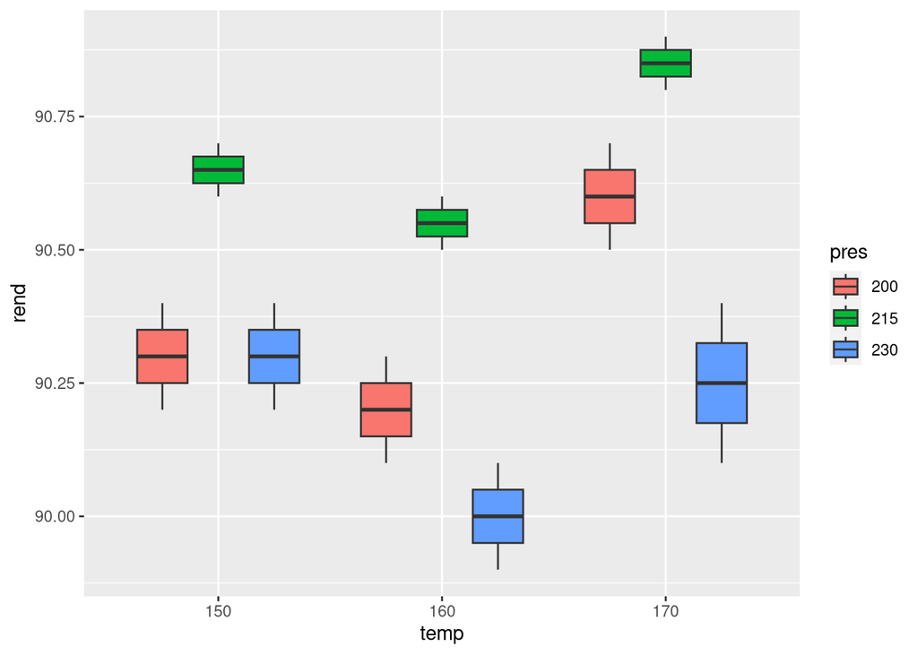

```r
library(ggplot2)

ggplot(data = quimico, mapping = aes(x = temp,y = rend, fill = pres)) + geom_boxplot()
```

Para fazer a análise da variância de dois fatores alguns pressupostos devem ser atendidos, sendo eles o pressuposto de normalidade dos resíduos do modelo e o pressuposto de homogeneidade da variância. Todos os pressupostos da ANOVA foram atendidos pelos testes de Shapiro-Wilk e Bartlett.

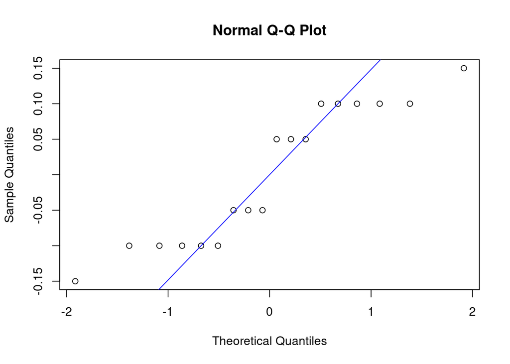

```r
anova <- aov(rend~temp*pres, data = quimico)

  # variable normatility
qqnorm(residuals(anova))
qqline(residuals(anova), col='blue')
```

```r
shapiro.test(quimico$rend)
```

```
##
##  Shapiro-Wilk normality test
##
## data:  quimico$rend
## W = 0.97363, p-value = 0.8625
```

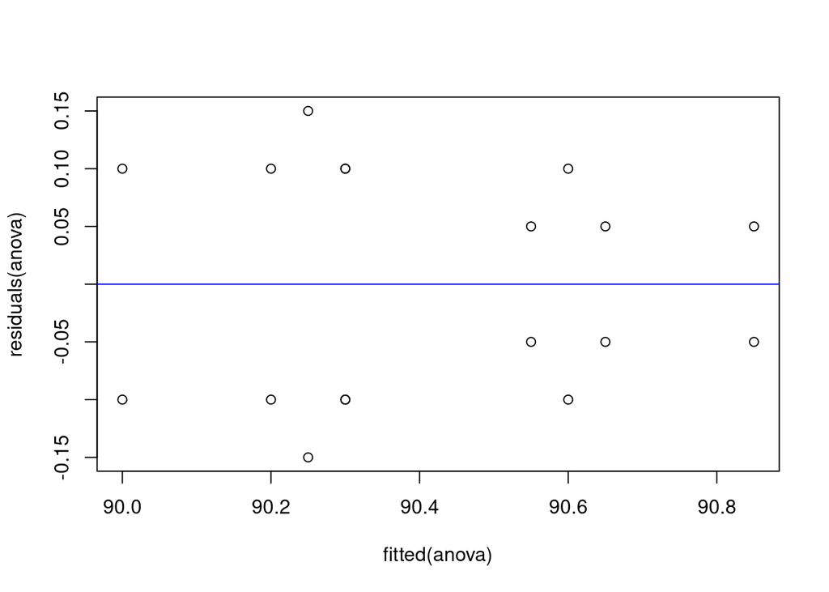

```r
  # homocedasticity of variance
plot(fitted(anova), residuals(anova))
abline(h=0, col='blue')
```

```r
bartlett.test(rend~interaction(temp,pres), data = quimico)
```

```
##
##  Bartlett test of homogeneity of variances
##
## data:  rend by interaction(temp, pres)
## Bartlett's K-squared = 1.6696, df = 8, p-value = 0.9895
```

```r
  # independence of variables
chisq.test(table(quimico$temp, quimico$pres))
```

```
##
##  Pearson's Chi-squared test
##
## data:  table(quimico$temp, quimico$pres)
## X-squared = 0, df = 4, p-value = 1
```

Para interpretar os resultados da ANOVA de dois fatores precisamos levar em consideração a $H_0$ de que a interação das variáveis explicativas não é significativa, se a mesma não for significativa os efeitos principais podem ser analisados separadamente, contudo se ela for significativa para o problema em questão os efeitos principais não são passíveis de interpretação separadamente e então a interação entre as variáveis que deve ser interpretada.

Para a análise da variabilidade no rendimento do processo químico notamos que a hipótese nula da interação entre a temperatura e a pressão não é significativa para explicar a variabilidade do processo, logo podemos fazer a análise dos efeitos principais separadamente.

```r
summary(anova)
```

```
##             Df Sum Sq Mean Sq F value   Pr(>F)
## temp         2 0.3011  0.1506   8.469 0.008539 **
## pres         2 0.7678  0.3839  21.594 0.000367 ***
## temp:pres    4 0.0689  0.0172   0.969 0.470006
## Residuals    9 0.1600  0.0178
## ---
## Signif. codes:  0 '***' 0.001 '**' 0.01 '*' 0.05 '.' 0.1 ' ' 1
```

```r
# efeito principasl da temperatura
tukey_temp <- HSD.test(y = quimico$rend, trt = quimico$temp,
                       DFerror = anova$df.residual,
                       MSerror = summary(anova)[[1]][4,3],
                       alpha = 0.05, console = TRUE)
```

```
##
## Study: quimico$rend ~ quimico$temp
##
## HSD Test for quimico$rend
##
## Mean Square Error:  0.01777778
##
## quimico$temp,  means
##
##     quimico.rend       std r         se  Min  Max    Q25  Q50    Q75
## 150     90.41667 0.2041241 6 0.05443311 90.2 90.7 90.250 90.4 90.550
## 160     90.25000 0.2664583 6 0.05443311 89.9 90.6 90.100 90.2 90.450
## 170     90.56667 0.2943920 6 0.05443311 90.1 90.9 90.425 90.6 90.775
##
## Alpha: 0.05 ; DF Error: 9
## Critical Value of Studentized Range: 3.948492
##
## Minimun Significant Difference: 0.2149287
##
## Treatments with the same letter are not significantly different.
##
##     quimico$rend groups
## 170     90.56667      a
## 150     90.41667     ab
## 160     90.25000      b
```

```r
# efeito principal da pressão
tukey_pres <- HSD.test(y = quimico$rend, trt = quimico$pres,
                       DFerror = anova$df.residual,
                       MSerror = summary(anova)[[1]][4,3],
                       alpha = 0.05, console = TRUE)
```

```
##
## Study: quimico$rend ~ quimico$pres
##
## HSD Test for quimico$rend
##
## Mean Square Error:  0.01777778
##
## quimico$pres,  means
##
##     quimico.rend       std r         se  Min  Max    Q25   Q50    Q75
## 200     90.36667 0.2160247 6 0.05443311 90.1 90.7 90.225 90.35 90.475
## 215     90.68333 0.1471960 6 0.05443311 90.5 90.9 90.600 90.65 90.775
## 230     90.18333 0.1940790 6 0.05443311 89.9 90.4 90.100 90.15 90.350
##
## Alpha: 0.05 ; DF Error: 9
## Critical Value of Studentized Range: 3.948492
##
## Minimun Significant Difference: 0.2149287
##
## Treatments with the same letter are not significantly different.
##
##     quimico$rend groups
## 215     90.68333      a
## 200     90.36667      b
## 230     90.18333      b
```

##### Problema 2

Um engenheiro suspeita que o acabamento superficial de uma peça de metal é influenciado pela taxa de avanço e pela profundidade de corte. Ele seleciona três taxas de avanço e quatro profundidades de corte. Ele então conduz um experimento fatorial e obtém:

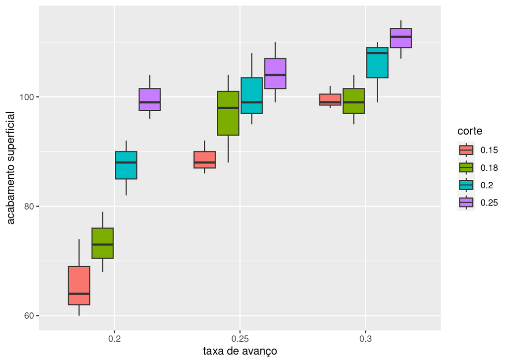

```r
metal <- data.frame(taxa = factor(c(rep(0.20,12), rep(0.25,12), rep(0.30,12))),
                    corte = factor(rep(c(rep(0.15,3), rep(0.18,3),
                                         rep(0.20,3), rep(0.25,3)),3)),
                    acabam = c(74,64,60,79,68,73,82,88,92,99,104,96,92,
                               86,88,98,104,88,99,108,95,104,110,99,99,
                               98,102,104,99,95,108,110,99,114,111,107))

ggplot(data = metal, mapping = aes(x = taxa, y = acabam, fill = corte)) +
  geom_boxplot() + xlab("taxa de avanço") + ylab("acabamento superficial")
```

Ao analisar a dispersão dos dados notamos que ao aumentar a profundidade de corte o acabamento superficial tende a aumentar, isso em todas as taxas de avanço. Para maior precisão na análise a ANOVA é conduzida.

Para conduzir essa análise os pressupostos devem ser atendidos, para tal o Teste de normalidade Shapiro-Wilk é realizado sob hipótese nula de que os resíduos do modelo são normalmente distribuidos e ao nível de significância de 5% a hipótese não é rejeitada, a análise gráfica complementa essa conclusão ao mostrar como as observações centrais se aproximam da reta de normalidade. O pressuposto de homocedasticidade têm sob $H_0$ a hipótese de que há homogeneidade nas variâncias, e dado o valor de p não significativo a $H_0$ não é rejeitada. E o pressuposto de independência das variáveis explicativas sob $H_0$ das variáveis serem independentes não é rejeitado para os dados de estudo.

```r
anova2 <- aov(acabam~taxa*corte, data = metal)

# pressupostos:
  # normalidade da variável resposta
shapiro.test(residuals(anova2))
```

```
##
##  Shapiro-Wilk normality test
##
## data:  residuals(anova2)
## W = 0.97051, p-value = 0.4397
```

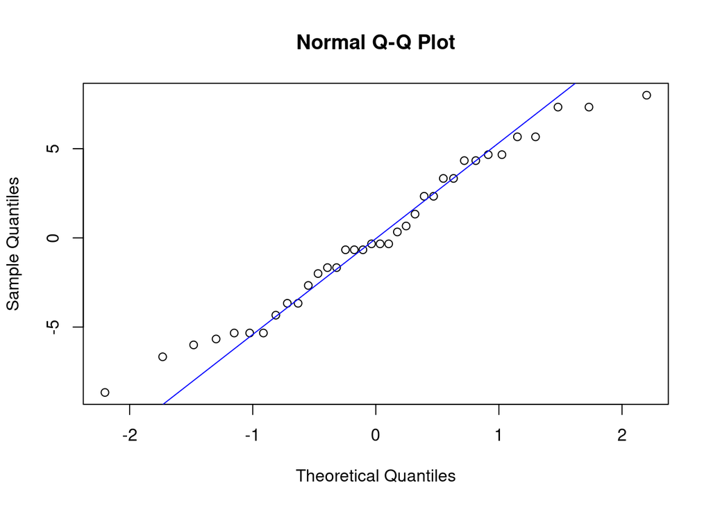

```r
qqnorm(residuals(anova2))
qqline(residuals(anova2), col='blue')
```

```r
  # homogeneidade das variâncias
bartlett.test(acabam~interaction(taxa,corte), data = metal)
```

```
##
##  Bartlett test of homogeneity of variances
##
## data:  acabam by interaction(taxa, corte)
## Bartlett's K-squared = 4.6743, df = 11, p-value = 0.9459
```

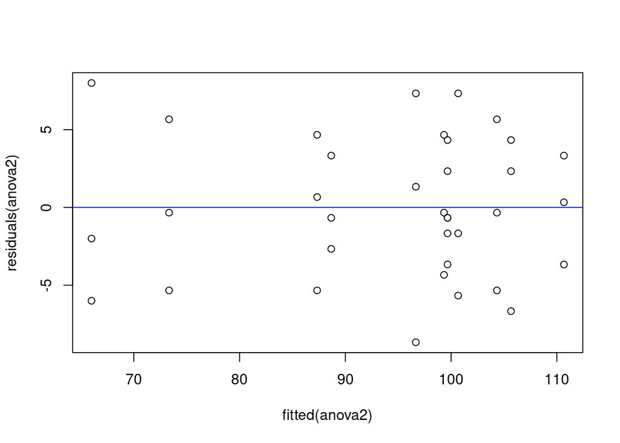

```r
plot(fitted(anova2), residuals(anova2))
abline(h=0, col='blue')
```

```r
  # independência das variáveis explicativas
chisq.test(table(metal$taxa, metal$corte))
```

```
##
##  Pearson's Chi-squared test
##
## data:  table(metal$taxa, metal$corte)
## X-squared = 0, df = 6, p-value = 1
```

A interação dos tratamentos é significativa portanto não é possível analisar os efeitos principais separadamente, é necessária analisar a interação dos mesmos. Para isso primeiro se analisa a interação da profundidade de corte dentro de cada taxa de avanço e depois se analisa a taxa de avanço dentro de cada profundidade de corte.

```r
summary(anova2)
```

```
##             Df Sum Sq Mean Sq F value   Pr(>F)
## taxa         2 3160.5  1580.2  55.018 1.09e-09 ***
## corte        3 2125.1   708.4  24.663 1.65e-07 ***
## taxa:corte   6  557.1    92.8   3.232    0.018 *
## Residuals   24  689.3    28.7
## ---
## Signif. codes:  0 '***' 0.001 '**' 0.01 '*' 0.05 '.' 0.1 ' ' 1
```

```r
mod_inter <- aov(acabam ~ taxa/corte, data = metal)
names(coef(mod_inter))[4:12]
```

```
## [1] "taxa0.2:corte0.18"  "taxa0.25:corte0.18" "taxa0.3:corte0.18"
## [4] "taxa0.2:corte0.2"   "taxa0.25:corte0.2"  "taxa0.3:corte0.2"
## [7] "taxa0.2:corte0.25"  "taxa0.25:corte0.25" "taxa0.3:corte0.25"
```

```r
# estudando a profundidade de corte dentro de cada taxa de avanço
summary(mod_inter, split = list("taxa:corte" = list("corte d. taxa 0.2" = c(1,4,7),
                                                    "corte d. taxa 0.25" = c(2,5,8),
                                                    "corte d. taxa 0.3" = c(3,6,9))))
```

```
##                                  Df Sum Sq Mean Sq F value   Pr(>F)
## taxa                              2 3160.5  1580.2  55.018 1.09e-09 ***
## taxa:corte                        9 2682.2   298.0  10.376 2.39e-06 ***
##   taxa:corte: corte d. taxa 0.2   3 2012.9   671.0  23.361 2.68e-07 ***
##   taxa:corte: corte d. taxa 0.25  3  406.2   135.4   4.715   0.0100 *
##   taxa:corte: corte d. taxa 0.3   3  263.0    87.7   3.052   0.0479 *
## Residuals                        24  689.3    28.7
## ---
## Signif. codes:  0 '***' 0.001 '**' 0.01 '*' 0.05 '.' 0.1 ' ' 1
```

```r
# estudando a taxa de avanço dentro de cada profundidade

mod_inter2 <- aov(acabam ~ corte/taxa, data=metal)
names(coef(mod_inter2))[5:12]
```

```
## [1] "corte0.15:taxa0.25" "corte0.18:taxa0.25" "corte0.2:taxa0.25"
## [4] "corte0.25:taxa0.25" "corte0.15:taxa0.3"  "corte0.18:taxa0.3"
## [7] "corte0.2:taxa0.3"   "corte0.25:taxa0.3"
```

```r
summary(mod_inter2, split = list("corte:taxa" = list("taxa d. corte 0.15" = c(1,5),
                                                     "taxa d. corte 0.18" = c(2,6),
                                                     "taxa d. corte 0.20" = c(3,7),
                                                     "taxa d. corte 0.25" = c(4,8))))
```

```
##                                  Df Sum Sq Mean Sq F value   Pr(>F)
## corte                             3   2125   708.4  24.663 1.65e-07 ***
## corte:taxa                        8   3718   464.7  16.179 6.12e-08 ***
##   corte:taxa: taxa d. corte 0.15  2   1768   884.1  30.781 2.37e-07 ***
##   corte:taxa: taxa d. corte 0.18  2   1228   613.8  21.369 4.68e-06 ***
##   corte:taxa: taxa d. corte 0.20  2    539   269.4   9.381 0.000977 ***
##   corte:taxa: taxa d. corte 0.25  2    183    91.4   3.184 0.059378 .
## Residuals                        24    689    28.7
## ---
## Signif. codes:  0 '***' 0.001 '**' 0.01 '*' 0.05 '.' 0.1 ' ' 1
```

Fazendo o Teste de comparações múltiplas de Tukey das profundidades de corte dentro de cada taxa de avanço observamos que para a taxa de avanço de 0.20 in/min as profundidades de corte de 0.18 e 0.15in não são significativamente diferentes entre si. Já para a taxa de avanço de 0.30in podemos notar pelo teste de Tukey que nenhuma das profundidades de corte são significativamente diferentes entre si.

```r
# profundidades de corte dentro da taxa de avanço de 0.20 in/min
HSD.test(y = metal$acabam[metal$taxa == "0.2"],
         trt = metal$corte[metal$taxa == "0.2"],
         DFerror = anova2$df.residual, alpha = 0.05,
         MSerror = summary(anova2)[[1]][4,3], group = TRUE,
         console = TRUE)
```

```
##
## Study: metal$acabam[metal$taxa == "0.2"] ~ metal$corte[metal$taxa == "0.2"]
##
## HSD Test for metal$acabam[metal$taxa == "0.2"]
##
## Mean Square Error:  28.72222
##
## metal$corte[metal$taxa == "0.2"],  means
##
##      metal.acabam.metal.taxa.....0.2..      std r     se Min Max  Q25 Q50   Q75
## 0.15                          66.00000 7.211103 3 3.0942  60  74 62.0  64  69.0
## 0.18                          73.33333 5.507571 3 3.0942  68  79 70.5  73  76.0
## 0.2                           87.33333 5.033223 3 3.0942  82  92 85.0  88  90.0
## 0.25                          99.66667 4.041452 3 3.0942  96 104 97.5  99 101.5
##
## Alpha: 0.05 ; DF Error: 24
## Critical Value of Studentized Range: 3.901262
##
## Minimun Significant Difference: 12.07129
##
## Treatments with the same letter are not significantly different.
##
##      metal$acabam[metal$taxa == "0.2"] groups
## 0.25                          99.66667      a
## 0.2                           87.33333      b
## 0.18                          73.33333      c
## 0.15                          66.00000      c
```

```r
# profundidades de corte dentro da taxa de avanço de 0.30 in/min
HSD.test(y = metal$acabam[metal$taxa == "0.3"],
         trt = metal$corte[metal$taxa == "0.3"],
         DFerror = anova2$df.residual, alpha = 0.05, group = TRUE,
         MSerror = summary(anova2)[[1]][4,3], console = TRUE)
```

```
##
## Study: metal$acabam[metal$taxa == "0.3"] ~ metal$corte[metal$taxa == "0.3"]
##
## HSD Test for metal$acabam[metal$taxa == "0.3"]
##
## Mean Square Error:  28.72222
##
## metal$corte[metal$taxa == "0.3"],  means
##
##      metal.acabam.metal.taxa.....0.3..      std r     se Min Max   Q25 Q50
## 0.15                          99.66667 2.081666 3 3.0942  98 102  98.5  99
## 0.18                          99.33333 4.509250 3 3.0942  95 104  97.0  99
## 0.2                          105.66667 5.859465 3 3.0942  99 110 103.5 108
## 0.25                         110.66667 3.511885 3 3.0942 107 114 109.0 111
##        Q75
## 0.15 100.5
## 0.18 101.5
## 0.2  109.0
## 0.25 112.5
##
## Alpha: 0.05 ; DF Error: 24
## Critical Value of Studentized Range: 3.901262
##
## Minimun Significant Difference: 12.07129
##
## Treatments with the same letter are not significantly different.
##
##      metal$acabam[metal$taxa == "0.3"] groups
## 0.25                         110.66667      a
## 0.2                          105.66667      a
## 0.15                          99.66667      a
## 0.18                          99.33333      a
```

Já ao fazermos o teste de comparações múltiplas para as taxas de avanço dentro de cada profundidade de corte começando pela profundidade de 0.18 in temos que as taxas de avanço de 0.3 e 0.25 não são significativamente diferentes, já ao analisar as taxas de avanço para a profundidade de corte de 0.25in notamos que a taxa de avanço de 0.25in não significativamente diferente das outras.

```r
# taxa de avanço dentro da profundidades de corte 0.18in
HSD.test(y = metal$acabam[metal$corte == "0.18"],
         trt = metal$taxa[metal$corte == "0.18"],
         DFerror = anova2$df.residual, alpha = 0.05, group = TRUE,
         MSerror = summary(anova2)[[1]][4,3], console = TRUE)
```

```
##
## Study: metal$acabam[metal$corte == "0.18"] ~ metal$taxa[metal$corte == "0.18"]
##
## HSD Test for metal$acabam[metal$corte == "0.18"]
##
## Mean Square Error:  28.72222
##
## metal$taxa[metal$corte == "0.18"],  means
##
##      metal.acabam.metal.corte.....0.18..      std r     se Min Max  Q25 Q50
## 0.2                             73.33333 5.507571 3 3.0942  68  79 70.5  73
## 0.25                            96.66667 8.082904 3 3.0942  88 104 93.0  98
## 0.3                             99.33333 4.509250 3 3.0942  95 104 97.0  99
##        Q75
## 0.2   76.0
## 0.25 101.0
## 0.3  101.5
##
## Alpha: 0.05 ; DF Error: 24
## Critical Value of Studentized Range: 3.531697
##
## Minimun Significant Difference: 10.92778
##
## Treatments with the same letter are not significantly different.
##
##      metal$acabam[metal$corte == "0.18"] groups
## 0.3                             99.33333      a
## 0.25                            96.66667      a
## 0.2                             73.33333      b
```

```r
# taxa de avanço dentro da profundidades de corte 0.25in
HSD.test(y = metal$acabam[metal$corte == "0.25"],
         trt = metal$taxa[metal$corte == "0.25"],
         DFerror = anova2$df.residual, alpha = 0.05, group = TRUE,
         MSerror = summary(anova2)[[1]][4,3], console = TRUE)
```

```
##
## Study: metal$acabam[metal$corte == "0.25"] ~ metal$taxa[metal$corte == "0.25"]
##
## HSD Test for metal$acabam[metal$corte == "0.25"]
##
## Mean Square Error:  28.72222
##
## metal$taxa[metal$corte == "0.25"],  means
##
##      metal.acabam.metal.corte.....0.25..      std r     se Min Max   Q25 Q50
## 0.2                             99.66667 4.041452 3 3.0942  96 104  97.5  99
## 0.25                           104.33333 5.507571 3 3.0942  99 110 101.5 104
## 0.3                            110.66667 3.511885 3 3.0942 107 114 109.0 111
##        Q75
## 0.2  101.5
## 0.25 107.0
## 0.3  112.5
##
## Alpha: 0.05 ; DF Error: 24
## Critical Value of Studentized Range: 3.531697
##
## Minimun Significant Difference: 10.92778
##
## Treatments with the same letter are not significantly different.
##
##      metal$acabam[metal$corte == "0.25"] groups
## 0.3                            110.66667      a
## 0.25                           104.33333     ab
## 0.2                             99.66667      b
```

##### Problema 3

Um artigo no Industrial Quality Control (1956, pp.5–8) descreve um experimento para investigar o efeito do tipo de vidro e do tipo de fósforo no brilho de um tubo de televisão. A variável de resposta é a corrente necessária (em microamperes) para obter um nível de correção especificado. Os dados são os seguintes:

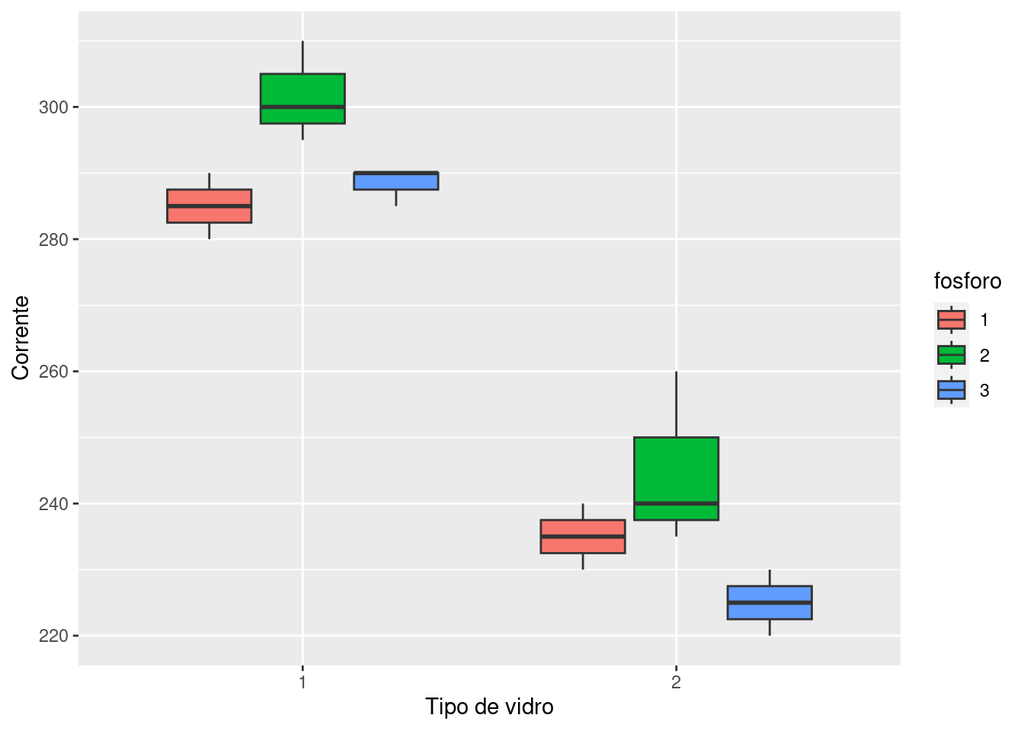

```r
tv <- data.frame(vidro = factor(c(rep(1,9), rep(2,9))),
                 fosforo = factor(rep(c(rep(1,3), rep(2,3), rep(3,3)),2)),
                 corrent = c(280,290,285,300,310,295,290,285,290,230,235,240,260,240,235,220,225,230))

ggplot(data = tv, mapping = aes(x = vidro, y = corrent, fill = fosforo)) +
  geom_boxplot() + xlab("Tipo de vidro") + ylab("Corrente")
```

Pela análise gráfica podemos notar que os tipos de vidro têm médias de corrente diferentes, e mesmo entre os tipos de fósforos as medidas se diferenciam relativamente. Para verificar se esses tratamentos têm mesmo influência na corrente elétrica necessária fazemos a análise da variância, para tal os pressupostos de normalidade dos resíduos, homogeneidade da variância e independência das variáveis foi atendido.

```r
# modelo
anova3 <- aov(corrent~vidro*fosforo, data = tv)

# pressupostos
  #normalidade da variável resposta
shapiro.test(residuals(anova3))
```

```
##
##  Shapiro-Wilk normality test
##
## data:  residuals(anova3)
## W = 0.9525, p-value = 0.4655
```

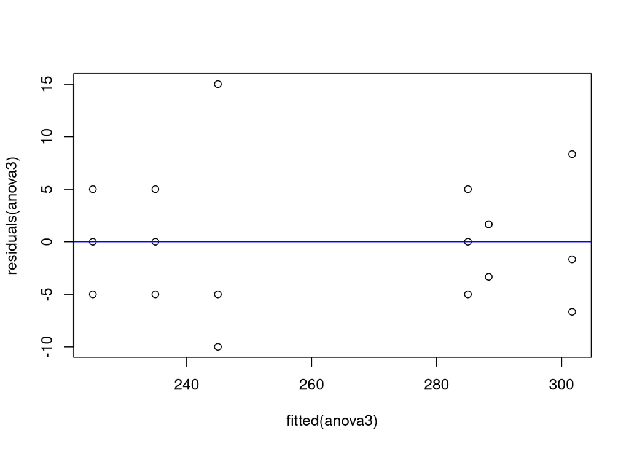

```r
  #homogeneidade das variâncias
plot(fitted(anova3), residuals(anova3))
abline(h=0, col='blue')
```

```r
bartlett.test(corrent~interaction(vidro,fosforo), data=tv)
```

```
##
##  Bartlett test of homogeneity of variances
##
## data:  corrent by interaction(vidro, fosforo)
## Bartlett's K-squared = 4.6694, df = 5, p-value = 0.4575
```

```r
  #independência das variáveis explicativas
chisq.test(table(tv$vidro, tv$fosforo))
```

```
##
##  Pearson's Chi-squared test
##
## data:  table(tv$vidro, tv$fosforo)
## X-squared = 0, df = 2, p-value = 1
```

```r
# análise
summary(anova3)
```

```
##               Df Sum Sq Mean Sq F value   Pr(>F)
## vidro          1  14450   14450 273.789 1.26e-09 ***
## fosforo        2    933     467   8.842  0.00436 **
## vidro:fosforo  2    133      67   1.263  0.31780
## Residuals     12    633      53
## ---
## Signif. codes:  0 '***' 0.001 '**' 0.01 '*' 0.05 '.' 0.1 ' ' 1
```

A interação dos tratamentos de tipo de vidro e tipo de fósforo no brilho de um tubo de televisão não é significativa portanto os efeitos principais podem ser analisados separadamente. E por meio do Post Hoc de diferenças mínimas de Tukey temos que os tipos de fósforo 1 e 3 não são significativamente diferentes entre si.

```r
# efeito principal do tipo de fosforo
tukey_fosf <- HSD.test(y = tv$corrent, trt = tv$fosforo, alpha = 0.05,
                      DFerror = anova3$df.residual, console = T,
                      MSerror = summary(anova3)[[1]][4,3]
)
```

```
##
## Study: tv$corrent ~ tv$fosforo
##
## HSD Test for tv$corrent
##
## Mean Square Error:  52.77778
##
## tv$fosforo,  means
##
##   tv.corrent      std r       se Min Max    Q25   Q50    Q75
## 1   260.0000 27.74887 6 2.965855 230 290 236.25 260.0 283.75
## 2   273.3333 32.50641 6 2.965855 235 310 245.00 277.5 298.75
## 3   256.6667 34.88075 6 2.965855 220 290 226.25 257.5 288.75
##
## Alpha: 0.05 ; DF Error: 12
## Critical Value of Studentized Range: 3.772929
##
## Minimun Significant Difference: 11.18996
##
## Treatments with the same letter are not significantly different.
##
##   tv$corrent groups
## 2   273.3333      a
## 1   260.0000      b
## 3   256.6667      b
```